# Interim_Report - NLP Text Prediction

N

November 23, 2018

## Initial Analysis

Our initial analysis created 3 raw files of complete input text {twitter, blog, news} which was then sampled to create c.400k samples of each {twitterSample, blogSample, newsSample} and 3 test files of the same size {twitterTest, blogTest, newsTest}.

At this point the initial view of the predictor was that some data features needed cleaning: - emojis were removed to allow functions to run - text was converted into UTF-8 format to remove non-alphabet charectors - all text was put to lower case - some spurious stop-words were excluded - all stopwords were removed in one version, but this was later found to be un-helpful to the prediction work - @user and #hashtags were removed

```r
t1<-length(twitter);t2<-max(nchar(as.character(twitter)));
n1<-length(news);n2<-max(nchar(as.character(news)));
b1<-length(blog);b2<-max(nchar(as.character(blog)));
t1;n1;b1; # number of rows
t2;n2;b2; #mximum row length
```

[output not shown]

We have sampled 400k records from each of Twitter (2,360,148 records) at 17%, News (1,010,242 records) at 39% and Blog (899,288 records) at 44% of the underlying data. This should give a good representation of the data and larger samples would take a long time to run.

## Create Ngrams

To create an effective text predictor, we need to look at the structure of the sentances.

N-Grams break the words up into chunks that are easy to analyse i.e. 2-gram (hello-there), 3-gram (hello-there-are) 4-gram (hello-there-are-many) 5-gram (hello-there-are-many-words).

Some thought needs to be given to cleaning the data and to whether we include stop words (e.g. and, the, are).

To begin with, I will create 2,3,4-grams both with and without the stop words.

These will be exported to csv to create coding efficiency for model building steps.

N-grams with only 1 observation will be excluded to reduce the table sizes.

Analysis of the 1,2,3,4,5-grams are shown below the section on model building.

## Text Prediction - Katz Backoff Model

For text prediction, I will use the n-grams to create a loose approximation of the Katz Backoff Model.

The model starts by looking for string matches in the highest n-grams (I invesetigated up to 7-grams but due to dataset size and lack of matches am working with 5-grams as a maximum for my model). If a match is found in the 5-gram table, calculate the probability of a correct match by the observations from the test dataset.

Then, I will search down to lower levels of n-gram calculating the probability of each variable prediction and compare the likelihood of a correct prediction in the words.

For example the sentence: “The end of the” produces lots of matches in the 5-grams:

- “the end of the day” - 0.024% of the observed (the maximum)
- “the end of the year” - 0.018% of the oberved

In the 4-grams, the results are the same but the probabilities lower:

- “end of the day” - 0.009%
- “end of the year” - 0.007%

The 3-grams:

- “of the year” - 0.022%
- “of the day” - 0.017%

So, the result of the prediction would choose “day” as the most likely word based on the cleaned data.

As a final back-stop the 2-gram is available, however that should hold a lower weighting than the higher order n-grams as shown below the prediction would give a very different response:

- “the first” - 0.084% (maximum probabiltiy)
- “the same” - 0.065%
- …
- “the day” - 0.030%
- “the year” - 0.026%

More complex approaches are available including probability smoothing for sparse or un-observed n-grams as described here:

https://en.wikipedia.org/wiki/Katz%27s_back-off_model

My initial model will aim to be fairly simple as above with the possibility to enhance further once it is working.

## N-Gram Word-Chart, Word-Clouds and Creation of the Raw Files for Modelling

Each code block loads a “Corpus” for the ngram, joins the 3 files and creates the summary visulalisations. The N-grams are stored in .csv format to avoid needing to re-run time-consuming code at the start of the mdoelling phase.

### Process the 1-grams and provide a barplot and word cloud of the 25 most prevalent

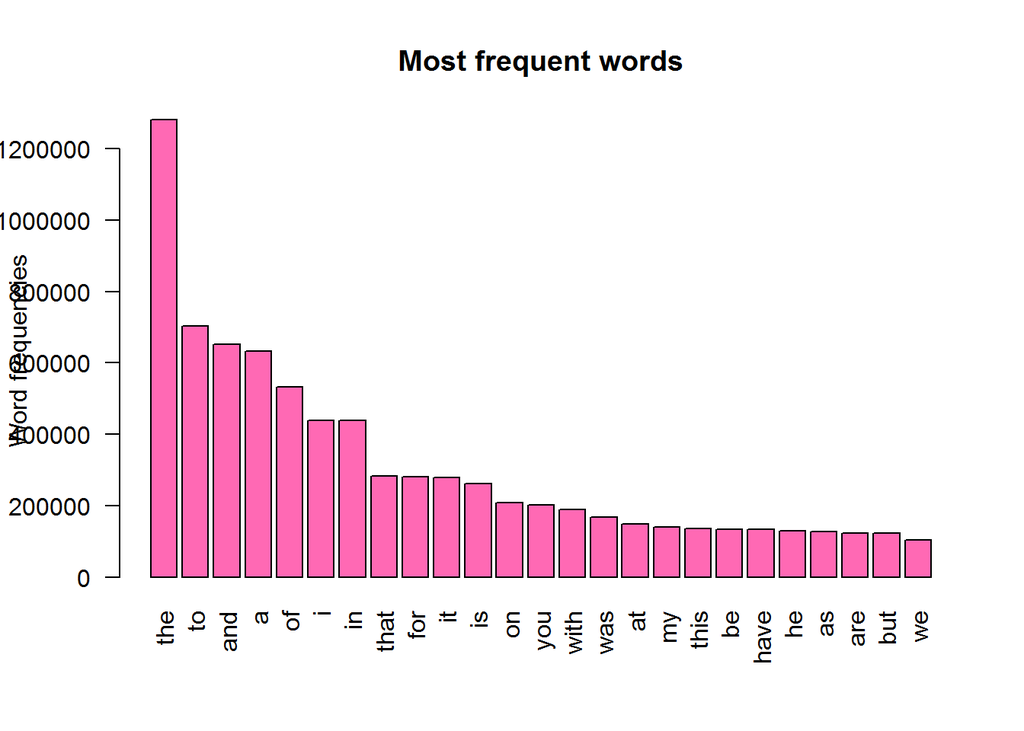

[interactive chart not shown]

```r
oneGramStop<-load.corpus.and.parse(files="all",corpus.dir="stopsample",encoding="ANSI",splitting.rule=" ",ngram.size = 1)

  #package the 3 datasets together and aggregate
  oneStop <- as.data.frame(aggregate(cbind(Freq) ~ Var1, rbind(as.data.frame(table(oneGramStop$blogSample)),as.data.frame(table(oneGramStop$newsSample)),as.data.frame(table(oneGramStop$twitterSample))), sum))
  oneStop<-oneStop[order(-oneStop$Freq),]
  oneStopSlim<-oneStop[oneStop$Freq>1,]  #cut anything fewer than 1 example

  ##create a word count chart
  par(mar=c(3,5,1,1))
  barplot(oneStopSlim[1:25,]$Freq, las = 2, names.arg = oneStopSlim[1:25,]$Var1,
          col ="hotpink", main ="Most frequent words",
          ylab = "Word frequencies")

  #create word cloud
  oneCloud<-wordcloud2(oneStopSlim[1:150, ], size = 1.5)

  saveRDS(oneStopSlim,"C:\\Nick\\07 R\\6JohnHopkins\\10 Capstone Project\\2 Exploration\\charts\\oneStopSlim.rds")
dev.off()
  saveRDS(oneCloud,"C:\\Nick\\07 R\\6JohnHopkins\\10 Capstone Project\\2 Exploration\\charts\\oneCloud.rds")

  write.csv(oneStopSlim,"C:\\Nick\\07 R\\6JohnHopkins\\10 Capstone Project\\2 Exploration\\input\\oneStop.csv")
```

### Process the 2-grams and provide a barplot and word cloud of the 25 most prevalent

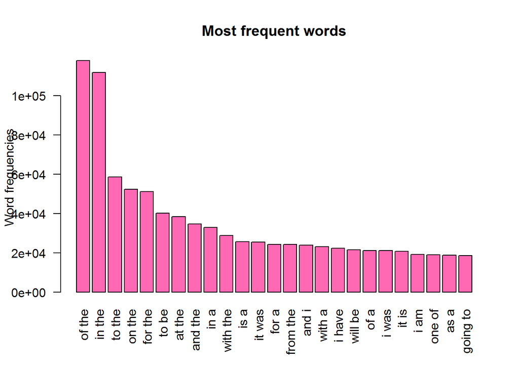

[interactive chart not shown]

```r
twoGramStop<-load.corpus.and.parse(files="all",corpus.dir="stopsample",encoding="ANSI",splitting.rule=" ",ngram.size = 2)

  #package the 3 datasets together and aggregate
  twoStop <- as.data.frame(aggregate(cbind(Freq) ~ Var1, rbind(as.data.frame(table(twoGramStop$blogSample)),as.data.frame(table(twoGramStop$newsSample)),as.data.frame(table(twoGramStop$twitterSample))), sum))
  twoStop<-twoStop[order(-twoStop$Freq),]
  twoStopSlim<-twoStop[twoStop$Freq>1,]  #cut anything fewer than 1 example

  ##create a word count chart
  par(mar=c(4,6,1,1))
  barplot(twoStopSlim[1:25,]$Freq, las = 2, names.arg = twoStopSlim[1:25,]$Var1,
          col ="hotpink", main ="Most frequent words",
          ylab = "Word frequencies")

  #create word cloud
  twoCloud<-wordcloud2(twoStopSlim[1:150, ], size = 1)

  saveRDS(twoStopSlim,"C:\\Nick\\07 R\\6JohnHopkins\\10 Capstone Project\\2 Exploration\\charts\\twoStopSlim.rds")
dev.off()
  saveRDS(twoCloud,"C:\\Nick\\07 R\\6JohnHopkins\\10 Capstone Project\\2 Exploration\\charts\\twoCloud.rds")

  #cut anything fewer than 1
  write.csv(twoStopSlim,"C:\\Nick\\07 R\\6JohnHopkins\\10 Capstone Project\\2 Exploration\\input\\twoStop.csv")
```

### Process the 3-grams and provide a barplot and word cloud of the 25 most prevalent

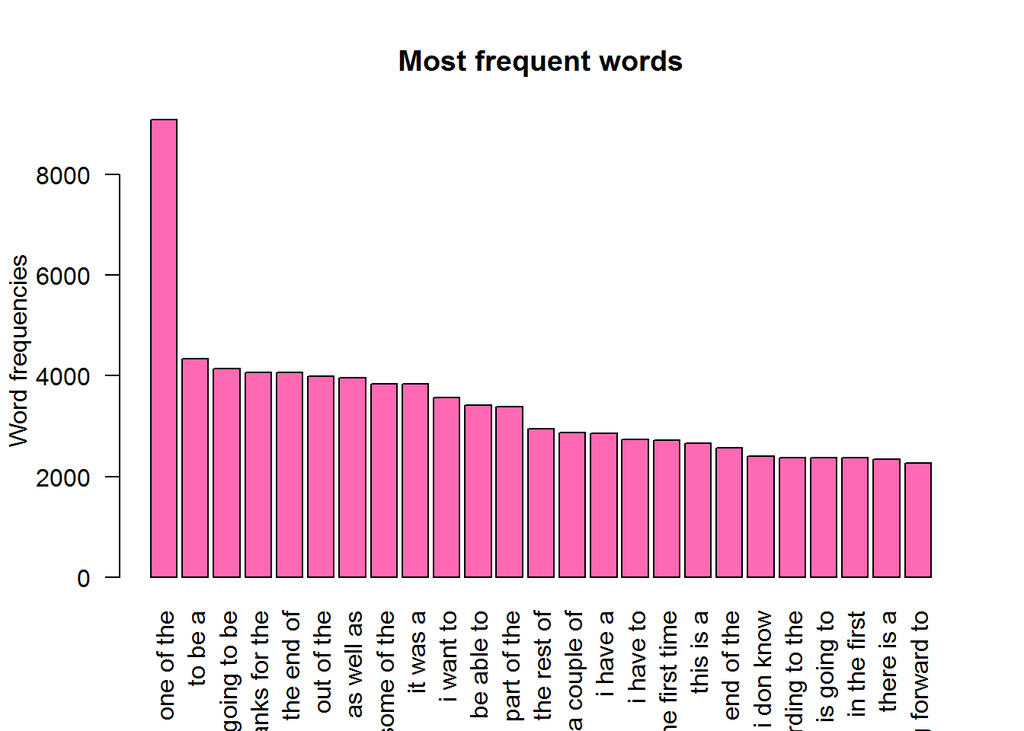

[interactive chart not shown]

```r
threeGramStop<-load.corpus.and.parse(files="all",corpus.dir="stopsample",encoding="ANSI",splitting.rule=" ",ngram.size = 3)
  #package the 3 datasets together and aggregate
  threeStop <- as.data.frame(aggregate(cbind(Freq) ~ Var1, rbind(as.data.frame(table(threeGramStop$blogSample)),as.data.frame(table(threeGramStop$newsSample)),as.data.frame(table(threeGramStop$twitterSample))), sum))
  threeStop<-threeStop[order(-threeStop$Freq),]
  threeStopSlim<-threeStop[threeStop$Freq>1,]  #cut anything fewer than 1 example

  ##create a word count chart
  par(mar=c(8,4,1,1))
  barplot(threeStopSlim[1:25,]$Freq, las = 2, names.arg = threeStopSlim[1:25,]$Var1,
          col ="hotpink", main ="Most frequent words",
          ylab = "Word frequencies")

  #create word cloud
  threeCloud<-wordcloud2(threeStopSlim[1:150, ], size = .75)

  saveRDS(threeStopSlim,"C:\\Nick\\07 R\\6JohnHopkins\\10 Capstone Project\\2 Exploration\\charts\\threeStopSlim.rds")
dev.off()
  saveRDS(threeCloud,"C:\\Nick\\07 R\\6JohnHopkins\\10 Capstone Project\\2 Exploration\\charts\\threeCloud.rds")

  write.csv(threeStopSlim,"C:\\Nick\\07 R\\6JohnHopkins\\10 Capstone Project\\2 Exploration\\input\\threeStop.csv")
```

### Process the 4-grams and provide a barplot and word cloud of the 25 most prevalent

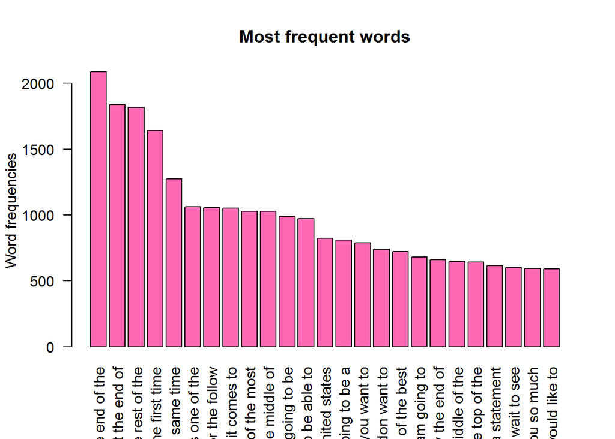

[interactive chart not shown]

```r
fourGramStop<-load.corpus.and.parse(files="all",corpus.dir="stopsample",encoding="ANSI",splitting.rule=" ",ngram.size = 4)

  #package the 3 datasets together and aggregate
  fourStop <- as.data.frame(aggregate(cbind(Freq) ~ Var1, rbind(as.data.frame(table(fourGramStop$blogSample)),as.data.frame(table(fourGramStop$newsSample)),as.data.frame(table(fourGramStop$twitterSample))), sum))
  fourStop<-fourStop[order(-fourStop$Freq),]
  fourStopSlim<-fourStop[fourStop$Freq>1,]  #cut anything fewer than 1 example

  ##create a word count chart
  par(mar=c(9,4,1,1))
  barplot(fourStopSlim[1:25,]$Freq, las = 2, names.arg = fourStopSlim[1:25,]$Var1,
          col ="hotpink", main ="Most frequent words",
          ylab = "Word frequencies")

  #create word cloud
  fourCloud<-wordcloud2(fourStopSlim[1:150, ], size = .5)

    saveRDS(fourStopSlim,"C:\\Nick\\07 R\\6JohnHopkins\\10 Capstone Project\\2 Exploration\\charts\\fourStopSlim.rds")
dev.off()
  saveRDS(fourCloud,"C:\\Nick\\07 R\\6JohnHopkins\\10 Capstone Project\\2 Exploration\\charts\\fourCloud.rds")

  write.csv(fourStopSlim,"C:\\Nick\\07 R\\6JohnHopkins\\10 Capstone Project\\2 Exploration\\input\\fourStop.csv")
```

NB The wordcloud and charts too large to generate correctly here so are excluded.

```r
fiveGramStop<-load.corpus.and.parse(files="all",corpus.dir="stopsample",encoding="ANSI",splitting.rule=" ",ngram.size = 5)

  #package the 3 datasets together and aggregate
  fiveStop <- as.data.frame(aggregate(cbind(Freq) ~ Var1, rbind(as.data.frame(table(fiveGramStop$blogSample)),as.data.frame(table(fiveGramStop$newsSample)),as.data.frame(table(fiveGramStop$twitterSample))), sum))
  fiveStop<-fiveStop[order(-fiveStop$Freq),]
  fiveStopSlim<-fiveStop[fiveStop$Freq>1,]  #cut anything fewer than 1 example

  ##create a word count chart
  par(mar=c(10,4,1,1))
  barplot(fiveStopSlim[1:25,]$Freq, las = 2, names.arg = fiveStopSlim[1:25,]$Var1,
          col ="hotpink", main ="Most frequent words",
          ylab = "Word frequencies")

  #create word cloud
  fiveCloud<-wordcloud2(fiveStopSlim[1:150, ], size = .5)

    saveRDS(fiveStopSlim,"C:\\Nick\\07 R\\6JohnHopkins\\10 Capstone Project\\2 Exploration\\charts\\fiveStopSlim.rds")
dev.off()
  saveRDS(fiveCloud,"C:\\Nick\\07 R\\6JohnHopkins\\10 Capstone Project\\2 Exploration\\charts\\fiveCloud.rds")

  write.csv(fiveStopSlim,"C:\\Nick\\07 R\\6JohnHopkins\\10 Capstone Project\\2 Exploration\\input\\fiveStop.csv")
```

## Appendices - Extract and Sample Data

### Original File Download

…and downloaded here:

```r
file<-"https://d396qusza40orc.cloudfront.net/dsscapstone/dataset/Coursera-SwiftKey.zip"
#download.file(file,"raw.zip")
```

### Install Required Packages

```r
library(stylo)      #corpus and ngrams
library(tm)         #NLP/text analysis
library(wordcloud2) #create the word cloud
```

### Initial Data Load

Now load the data using readlines and sample - currently using 400k records from each dataset. The encoding step helps handle awkward characters in the data. We also clean emojis from the twitter feed. Lastly we take a sample for train and test.

```r
#read the files
file1 <- "C:\\Nick\\07 R\\6JohnHopkins\\10 Capstone Project\\1 Data Exploration\\en_US\\twitterClean.txt"
file2 <- "C:\\Nick\\07 R\\6JohnHopkins\\10 Capstone Project\\1 Data Exploration\\en_US\\en_US.blogs.txt"
file3 <- "C:\\Nick\\07 R\\6JohnHopkins\\10 Capstone Project\\1 Data Exploration\\en_US_clean\\en_US.news_clean.txt"

#selecct UTF-8 to handle special charactors
twitter <- readLines(file1, skipNul = TRUE,encoding="UTF-8")
blog <- readLines(file2, skipNul = TRUE,encoding="UTF-8")
news <- readLines(file3, skipNul = TRUE,encoding="UTF-8")

#clean twitter
twitterClean<-gsub("[^\x01-\x7F]", "", twitter)

#create samples for next part of the analysis (10,000)
#Make some values NA so that we can predict to fill them...
sampSize<-400000
#set seed for reproducibility:
set.seed(123);
selectTW <- rbinom(length(twitterClean),size=1,prob=(sampSize/length(twitterClean)))==1
selectNW <- rbinom(length(news)[1],size=1,prob=(sampSize/length(news)))==1
selectBL <- rbinom(length(blog)[1],size=1,prob=(sampSize/length(blog)))==1

twitterSample<-twitterClean[selectTW];twitterTest<-twitterClean[-selectTW];
newsSample<-news[selectNW];newsTest<-news[-selectNW];
blogSample<-blog[selectBL];blogTest<-blog[-selectBL];

#outsample
testTW <- rbinom(length(twitterTest),size=1,prob=(sampSize/length(twitterTest)))==1
testNW <- rbinom(length(newsTest)[1],size=1,prob=(sampSize/length(newsTest)))==1
testBL <- rbinom(length(blogTest)[1],size=1,prob=(sampSize/length(blogTest)))==1

twitterTest<-twitterTest[testTW]
newsTest<-newsTest[testNW]
blogTest<-blogTest[testBL]
length(twitterTest);length(newsTest);length(blogTest)

#export to a new location for non-sequential running
setwd("C:\\Nick\\07 R\\6JohnHopkins\\10 Capstone Project\\2 Exploration\\sample\\")
writeLines(con = file("twitterSample.txt"),twitterSample)
writeLines(con = file("newsSample.txt"),newsSample)
writeLines(con = file("blogSample.txt"),blogSample)

setwd("C:\\Nick\\07 R\\6JohnHopkins\\10 Capstone Project\\2 Exploration\\test\\")
writeLines(con = file("twitterTest.txt"),twitterTest)
writeLines(con = file("newsTest.txt"),newsTest)
writeLines(con = file("blogTest.txt"),blogTest)
```

### Now Clean Up The Text

At first attempt stop-words were removed but then added back as this imporves the initial view of predictivity.

Other text processing completed - set to lower case - remove numbers - remove non-alphabet characters - remove @user and #hashtags - remove duplicate spaces

This gives cleaners datasets for the n-grams and text prediction later.

```r
#remove non-printable charactors, and convert "NULL" charecters to ASCII
#set to lower case
#remove stop words and twitter @users and #hashtags
stopWords<-c(c("rt","RT","amp","u.s.","u.s","p.m.","p.m","gt","g.t.","g.t","lt","l.t.","l.t","ny","n.y.","b","c","d","e","f","g","h","j","k","l","m","n","o","p","q","r","s","t","u","v","w","x","y","z"))  #add RT,rt to stopwords to clean up twitter



twitterStopSample<-gsub("'","",removeWords(trimws(gsub("\\s+"," ",gsub("\\s+|[^[:alnum:][:space:]']|[0-9]+", " ",gsub("\\s[#@]\\S+","",tolower(iconv(twitterSample,"ASCII","UTF-8","")))))),stopWords))
twitterStopTest<-gsub("'","",removeWords(trimws(gsub("\\s+"," ",gsub("\\s+|[^[:alnum:][:space:]']|[0-9]+", " ",gsub("\\s[#@]\\S+","",tolower(iconv(twitterTest,"ASCII","UTF-8","")))))),stopWords))
newsStopSample<-gsub("'","",removeWords(trimws(gsub("\\s+"," ",gsub("\\s+|[^[:alnum:][:space:]']|[0-9]+", " ",gsub("\\s[#@]\\S+","",tolower(iconv(iconv(newsSample,"latin1","ASCII"),"ASCII","UTF-8","")))))),stopWords))
newsStopTest<-gsub("'","",removeWords(trimws(gsub("\\s+"," ",gsub("\\s+|[^[:alnum:][:space:]']|[0-9]+", " ",gsub("\\s[#@]\\S+","",tolower(iconv(iconv(newsTest,"latin1","ASCII"),"ASCII","UTF-8","")))))),stopWords))
blogStopSample<-gsub("'","",removeWords(trimws(gsub("\\s+"," ",gsub("\\s+|[^[:alnum:][:space:]']|[0-9]+", " ",gsub("\\s[#@]\\S+","",tolower(iconv(iconv(blogSample,"latin1","ASCII"),"ASCII","UTF-8","")))))),stopWords))
blogStopTest<-gsub("'","",removeWords(trimws(gsub("\\s+"," ",gsub("\\s+|[^[:alnum:][:space:]']|[0-9]+", " ",gsub("\\s[#@]\\S+","",tolower(iconv(iconv(blogTest,"latin1","ASCII"),"ASCII","UTF-8","")))))),stopWords))



#export to a new location for non-sequential running
setwd("C:\\Nick\\07 R\\6JohnHopkins\\10 Capstone Project\\2 Exploration\\stopsample\\")
writeLines(con = file("twitterSample.txt"),twitterStopSample)
writeLines(con = file("newsSample.txt"),newsStopSample)
writeLines(con = file("blogSample.txt"),blogStopSample)

setwd("C:\\Nick\\07 R\\6JohnHopkins\\10 Capstone Project\\2 Exploration\\stoptest\\")
writeLines(con = file("twitterTest.txt"),twitterStopTest)
writeLines(con = file("newsTest.txt"),newsStopTest)
writeLines(con = file("blogTest.txt"),blogStopTest)
```